# Project: Retrieval-Augmented Generation (RAG) System for Process Operations

CHEE4003: Special Topics A - Artificial Intelligence in Chemical Engineering

Published

October 6, 2026

## Context

Modern chemical engineering operations rely on large volumes of **technical documentation**, including operating manuals, sensor data, process guides, and risk assessments. Efficient access to this information is essential for safe operation, process understanding, and informed decision-making.

In practice, these resources are often distributed across multiple documents, making it difficult to locate and combine relevant information in real time. This challenge motivates the development of systems that integrate **information retrieval** with **context-aware response generation**.

In this assignment, you will develop **Retrieval-Augmented Generation (RAG)** system for a **pilot-scale distillation column**. The system will act as a **virtual operator assistant**, retrieving relevant information from technical documents and combining it with user queries to generate accurate, context-aware responses.

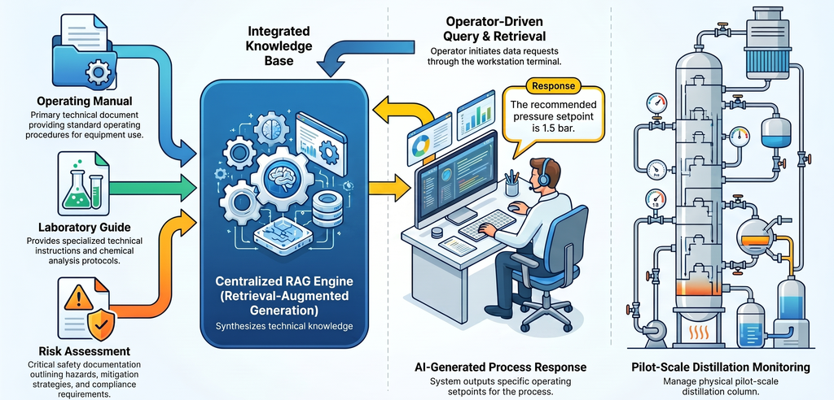

Figure 1: Conceptual illustration of a Retrieval-Augmented Generation (RAG) system for a pilot-scale distillation column, showing how technical documents are retrieved and integrated with user queries to generate context-aware, domain-informed operator responses.

Although illustrated through a distillation example, this application captures several important characteristics of real engineering decision-support systems:

- **Information retrieval:** Relevant knowledge must be identified from large and diverse technical sources (e.g., sensor data, system properties, and operational guidelines)
- **Context integration:** Retrieved information must be adapted and combined with the specific problem context, rather than used in isolation
- **Domain grounding:** Outputs must reflect reliable, discipline-specific principles, ensuring technical accuracy and physical consistency
- **Reasoning capability:** Results should support interpretation and decision-making under varying conditions, constraints, and objectives

These features make RAG a representative example of a **knowledge-assisted decision support system**, where combining reliable information retrieval with contextual reasoning is more important than relying on isolated or purely generative responses in real engineering applications.

## Engineering Challenge

In practice, engineers must address three interconnected challenges:

**1. Information Retrieval:** Efficiently locating relevant information from large, unstructured technical document collections  
**2. Knowledge Integration:** Combining retrieved information with a language model to generate accurate, context-aware responses  
**3. Reliable Decision Support:** Ensuring responses are factually correct, concise, and suitable for operational use

These challenges arise because engineering knowledge is often **distributed, unstructured, and context-dependent**, making it difficult to directly extract actionable insights.

To address these challenges, you will apply a set of complementary approaches:

- **RAG system design** to integrate document retrieval with response generation
- **Prompt engineering and system configuration** to guide model behaviour and improve response quality
- **Performance evaluation using structured queries** to assess accuracy, relevance, and reliability of outputs

## Assignment Aim and Learning Objectives

The aim of this assignment is to develop your ability to design and implement AI systems for **engineering knowledge retrieval and decision support**, with a focus on integrating structured information sources with language models.

By completing this assignment, you should be able to:

- Prepare and **process technical documents** for retrieval (e.g., chunking and cleaning)
- Design and implement a **RAG system architecture** for engineering applications
- Select and justify appropriate **embedding models and language models**
- Apply **prompt engineering techniques** to guide accurate and reliable responses
- Evaluate system performance using **structured test queries and metrics**
- Understand and analyse system limitations, including **hallucination and retrieval errors**
- Communicate technical solutions clearly within an **engineering context**

## Tasks

This assignment consists of five assessed components based on the following supporting documents.

| Document | File |
| --- | --- |
| Distillation Column Operational Manual | PDF |
| Laboratory Practical Guide | PDF |
| Distillation Column Internal Dimensions | PDF |
| Laboratory Risk Assessment | PDF |
| Ethylene Glycol Safety Data Sheet | PDF |
| Water Safety Data Sheet | PDF |

This assignment consists of five assessed components based on the following supporting documents.

### Task 1 : AI Usage Statement (6 marks)

At the beginning of your submission (details below), include a statement (maximum 1 page) describing your use of generative AI tools (e.g., ChatGPT, Copilot, Claude).

Your statement should:

- Clearly indicate whether AI tools were used
- Describe how they were used (e.g., code generation, debugging, conceptual support)
- Critically evaluate their usefulness and limitations in the context of your work
- Reflect on key lessons learned and how you would improve your use of these tools in future work

If you did not use generative AI tools, provide an explanation for this choice.

### Task 2 : RAG System Design and Implementation (28 marks)

Using techniques introduced in **Week 10**, design, implement, and justify a complete RAG system.

Your analysis should:

- **Prepare the dataset for retrieval:** Load provided documents, define and justify an appropriate chunking strategy, and explain how preprocessing improves retrieval quality
- **Configure the system components:** Select and justify the embedding model and language model (LLM), considering hardware constraints and task requirements
- **Design the retrieval mechanism:** Select an appropriate similarity metric and top-$k$ value, justify retrieval parameters, and demonstrate improved search relevance
- **Develop effective prompts:** Structure prompts for accuracy and reliability, apply prompting strategies, and justify key prompt design choices

**ImportantImportant**

Only the documents provided above may be used.

**Note:** Retrieval improvements must demonstrate enhanced semantic retrieval relevance and contextual understanding. Approaches that only improve the identification of exact phrases, keywords, or specific text fragments within the documents, without improving retrieval relevance, will not be considered evidence of improved semantic search performance.

### Task 3 : Performance Evaluation (16 marks)

Evaluate chatbot performance using the **10 predefined test queries** provided below.

Your analysis should:

- **Generate and document responses:** Provide a response of **≤ 30 words** for each query, include metadata at the start of each response, and capture a screenshot showing the user query, chatbot response, and response time
- **Assess system accuracy:** Evaluate performance such that a response is considered **correct** if *at least one* of up to **three attempts** matches the expected answer, and demonstrate that the system achieves **≥ 70% accuracy** (i.e., at least 7 out of 10 correct answers)
- **Analyse hallucination behaviour:** Identify at least **one example of hallucination**, explain the likely cause (e.g., retrieval failure or prompt design issues), and propose **practical mitigation strategies**

**ImportantAccuracy Requirement**

Achievement of the **70% accuracy threshold** does not in itself constitute full marks. Higher marks require stronger performance, higher accuracy, and more thorough evaluation of system behaviour and limitations.

#### Test Queries

> **Q1:** Who is the manufacturer of the distillation process unit?  
> **Expected answer:** PIGNAT S.A.S.

> **Q2:** What is the maximum volume capacity of the boiler (B01)?  
> **Expected answer:** 10 liters

> **Q3:** What is the required PPE for running the column?  
> **Expected answer:** Trousers, closed shoes, lab coat, safety glasses, gloves

> **Q4:** If the steam flow meter (FT05) shows 150 lb/h, is this within the unit’s operating range?  
> **Expected answer:** Yes, the Vortex flow transmitter for steam (FT05) has a range of 19.84 to 165.35 lb/h.

> **Q5:** What are the specified nominal values for the reflux ratio during operation?  
> **Expected answer:** The nominal values are between 0.3 and 0.5.

> **Q6:** Why is the use of bleach or chlorinated products forbidden in the unit?  
> **Expected answer:** They can permanently damage the equipment by causing corrosion if left in the unit for several days.

> **Q7:** If the boiler level (LIC01) drops to 44%, which specific alarm triggers and what is its tag?  
> **Expected answer:** If it drops to 44%, the Low Level Safety Alarm (LSL01) will trigger because the limit is 45%.

> **Q8:** Compare the instrumentation used for level measurement in the boiler vs. the feed tank. Are they the same technology?  
> **Expected answer:** Yes, both the Boiler (LT01) and Feed Tank (LT03) use deltaP (differential pressure) measurement transmitters with a range of 0-10 kPa.

> **Q9:** How much did we pay to purchase the distillation column?  
> **Expected answer:** Not specified

> **Q10:** The vacuum pump (P06) is making a high-pitched whistling sound; is that normal for this model?  
> **Expected answer:** Not specified

**ImportantIndependent Evaluation**

In addition to the above test queries, **three unseen queries** derived from the provided documents will be used to assess retrieval quality, response accuracy, robustness, and the ability to identify when information is not specified.

Results will be considered when assessing the **Accuracy Evaluation** and **Hallucination Analysis** criteria for this task.

### Task 4 : Proposal of New RAG system (16 marks)

Discuss (maximum 3 pages) a proposed RAG system for a different chemical engineering application.

Your analysis should:

- **Define the engineering problem:** Clearly describe the application context and the decision-making challenge to be addressed
- **Identify required data sources:** Specify relevant documentation, datasets, and knowledge bases needed to support the system
- **Design the system architecture:** Propose an appropriate RAG system design, including implementation strategy and key components
- **Evaluate expected benefits:** Explain how the system would improve outcomes such as safety, efficiency, and decision quality

### Task 5 : Oral Presentation (34 marks)

Deliver an in-person presentation consisting of a **15-minute presentation** followed by **10 minutes of questions**.

Your presentation should:

- **Explain the RAG system architecture:** Clearly describe the system structure and key components
- **Justify design choices:** Present and justify key modelling, retrieval, and prompting decisions
- **Critically evaluate system performance:** Discuss limitations and propose realistic improvement strategies
- **Present the proposed RAG application:** Briefly describe the new chemical engineering application proposed in Task 4 and explain its potential value.
- **Demonstrate technical understanding:** Respond to questions on system architecture, implementation, and code functionality

## Submission

Submit your work via **Gradescope**. You are required to upload your files using the appropriate **Gradescope submission link**:  
1. **Report Submission** (PDF)  
2. **Code Submission** (`project.ipynb`)  
3. **Presentation Submission** (PDF slides)  
The requirements for each submission are described below.

### 1. Report

Submit a single, well-structured report of **15–17 pages** (use the space effectively), **excluding the Appendix from the page limit**. The report should be **clear, concise, and professionally presented**, and must include:

- Relevant **figures**, **tables**, and **results**
- **Complete written responses** to all tasks
- For the **best-performing model**, screenshots generated in Task 3 for test queries must be included in the **Appendix**, showing:
  - The user query
  - The chatbot response
  - The response time

**TipTip**

Use a **small number of high-quality, informative figures and tables**. Avoid repetitive or unnecessary figures.

**ImportantReport Requirements**

- Ensure all figures and tables are **clearly labelled** and **referenced in the text**
- Present results **succinctly**, emphasising **interpretation and insight** rather than raw outputs
- Marks are awarded for both **technical accuracy** and **engineering insight**

### 2. Code

Submit a single **Jupyter file** called `project.ipynb`. The code must be:

- **Well-organised** and **easy to read**
- Written using **meaningful** variable and function names
- **Properly commented** to explain key steps

**ImportantCode Requirements**

The submitted code script must:

- **Generate and reproduce** all analyses and results presented in the report.
- **Be submitted with the report** and be sufficiently documented for verification.

**Note:** The code will **not** be assessed using an autograder. Instead, it will be executed and reviewed manually by the teaching team to verify that the reported results can be reproduced. Students are responsible for ensuring that their code executes successfully and reproduces the results presented in their submission.

Failure to submit a code script, or submission of code that does not execute successfully and reproduce the reported results, will result in a **penalty of 50% of the total assignment mark**. This penalty will be applied regardless of the quality of the accompanying report.

### 3. Presentation

Submit the presentation slides as a PDF file. The slides should cover:

- An overview of the RAG system and its intended purpose.
- Dataset preparation, including document loading, preprocessing, and chunking strategy.
- Selection and justification of the embedding model and LLM.
- Retrieval system design, including similarity metric, retrieval parameters, and retrieval performance.
- Prompt design and justification.
- Performance evaluation results, including accuracy and hallucination analysis.
- Limitations of the current system and potential improvements.
- At least one slide describing a proposed RAG application, including the engineering challenge, required data sources, system architecture, and expected benefits.

**ImportantPresentation Requiments**

The presentation slides must be submitted via the designated **Gradescope Presentation Submission** link by the assignment deadline.

Failure to submit the presentation slides will result in a **penalty of 50% of the total assignment mark**. This penalty will be applied regardless of the quality of the report, code, or subsequent oral presentation.

Students are required to deliver their presentation according to the schedule provided below.

## Marking Rubric

Marks are awarded based on the quality of analysis, interpretation, justification, and engineering insight. Higher marks require conclusions to be supported by appropriate evidence and clearly communicated.

**ImportantPerformance Expectations**

The workshop and case study examples provide a baseline approach for developing a functional RAG system. Correctly reproducing these approaches demonstrates competent achievement of the assignment requirements.

Higher marks require students to go beyond the demonstrated examples through independent optimisation, comparative evaluation of alternative approaches, evidence-based justification of design choices, and critical analysis of system limitations and opportunities for improvement.

### Assessment Criteria

| Task | Criterion | Description | Marks |
| --- | --- | --- | --- |
| **AI Usage Statement** | AI Usage Statement | Describes AI use (or non-use) and reflects on its benefits and limitations. | 6 |
| **RAG System Design and Implementation** | Dataset Preparation | Prepares documents for retrieval using an appropriate chunking and preprocessing strategy, with clear justification. | 7 |
|  | Model Configuration | Selects and justifies suitable embedding and language models for the task and available computational resources. | 6 |
|  | Retrieval Design and Evaluation | Configures and justifies retrieval parameters, similarity measure, and top-k selection. Demonstrates retrieval effectiveness. | 7 |
|  | Prompt Design and Justification | Develops structured prompts to improve response accuracy and reliability, and clearly justifies key prompt design choices. | 8 |
| **Performance Evaluation** | Response Generation | Provides responses, metadata, and screenshots for all 10 test queries. | 5 |
|  | Accuracy Evaluation | Assesses correctness using the prescribed test queries and demonstrates reliable performance across both prescribed and unseen queries. | 5 |
|  | Hallucination Analysis | Identifies and explains at least one hallucination, and proposes practical improvements to reduce hallucinations. | 6 |
| **Proposed RAG System** | Problem Definition | Clearly defines the chemical engineering application and decision-making challenge. | 3 |
|  | Data Sources | Identifies and justifies the documents, datasets, and knowledge sources required by the system. | 3 |
|  | System Architecture | Proposes and justifies the RAG system design, components, and implementation approach. | 5 |
|  | Expected Benefits | Explains how the system improves safety, efficiency, and decision-making. | 5 |
| **Oral Presentation** | RAG System Architecture | Clearly explains the system structure and key components. | 6 |
|  | Design Justification | Justifies key modelling, retrieval, and prompting decisions. | 6 |
|  | Performance Evaluation | Critically evaluates system performance, limitations, and potential improvements. | 6 |
|  | Proposed RAG Application | Clearly explains the proposed chemical engineering application, required data sources, system architecture, and expected benefits. | 6 |
|  | Technical Understanding and Discussion | Demonstrates understanding of the system, implementation, and code through responses to questions. | 10 |
| **Total** |  |  | **100** |

### Performance Levels

| Level | Percentage | General Descriptor |
| --- | --- | --- |
| **Exemplary** | **100%** | Demonstrates outstanding achievement of the criterion. Work is of exceptional quality, accuracy, completeness, and insight. |
| **Excellent** | **90%** | Demonstrates a strong achievement of the criterion. Work is accurate, thorough, and well-developed, with only minor limitations. |
| **Very Good** | **80%** | Demonstrates very good achievement of the criterion. Work is effective, accurate, and well-developed, with minor omissions or weaknesses. |
| **Good** | **70%** | Demonstrates competent achievement of the criterion. Work addresses most requirements appropriately, although depth, quality, accuracy, or completeness may be limited in places. |
| **Satisfactory** | **60%** | Demonstrates a basic achievement of the criterion. Work addresses key requirements but lacks consistency, depth, detail, or completeness. |
| **Mixed** | **50%** | Demonstrates partial achievement of the criterion. Work contains a mixture of strengths and weaknesses, including incomplete, inaccurate, or underdeveloped elements. |
| **Partially Correct** | **40%** | Demonstrates limited achievement of the criterion. Some requirements are addressed, but significant errors, omissions, or weaknesses reduce overall quality. |
| **Attempted** | **20%** | Demonstrates minimal achievement of the criterion. Work shows limited engagement with the requirements and provides little evidence of attainment. |
| **Not Attempted** | **0%** | Demonstrates no achievement of the criterion. The criterion has not been addressed, or no assessable evidence is provided. |

## Presentation Schedule

Students will deliver their oral presentation during **Week 13** on **29 or 30 October 2026**, during the scheduled time (**8:00 am - 12:00 pm**). Presentations will be held in **Building 46, Room 914**.

**ImportantAttendance and Confidentiality**

Students are required to attend their **entire allocated 4-hour session**, regardless of their scheduled presentation time.

To ensure fairness for all students, presentation questions and discussion topics must be treated as **confidential** and must not be shared with students presenting in subsequent session.

### Session 1: October 29, 2026

| Time | Student |
| --- | --- |
| 8:00 - 8:30 | Meera Alhammadi |
| 8:30 - 9:00 | Ruben Beaumont |
| 9:00 - 9:30 | Kierren Cheng |
| 9:30 - 10:00 | Dominick Clancy |
| 10:00 - 10:30 | Lucas Hale |
| 10:30 - 11:00 | Noah Hosking |
| 11:00 - 11:30 | Finn Hutchings |
| 11:30 - 12:00 | Jaiden Loveday |

### Session 2: October 30, 2026

| Time | Student |
| --- | --- |
| 8:00 - 8:30 | Zac Macartney |
| 8:30 - 9:00 | Jessnee Ng |
| 9:00 - 9:30 | Harley Nowland |
| 9:30 - 10:00 | Harrison Pope |
| 10:00 - 10:30 | Matt Ralston |
| 10:30 - 11:00 | Karl Sterzl |
| 11:00 - 11:30 | Quang Thinh Tran |
| 11:30 - 12:00 | Ian van Wyk |